# 10. Table Pivots

## Motivation (read this section twice; thrice wouldn’t hurt either)

In this notebook we introduce another set of methods for manipulating data sets. Table pivots, which are related by not identical to the spreadsheet concept of a *pivot table*, are a way or rearranging the values in a table without adding or lossing any additional information. This is achieved by either making the table longer (more rows, fewer columns) or wider (more columns, fewer rows).

What sort of situations would require going between two different formats with a different number of rows? As an example, consider a hypothetical experiment where we measure the heights of 100 plants every morning for two weeks. There are two different ways to store this data. We could have 100 rows, one for each plant, with features `height_day1`, `height_day2`, and so on all the way through `height_day14`. Alternatively, we could have 1400 rows with just three columns: an id for the plant, a feature for the day, and a feature for height. Notice that both of these options capture the same information, but each privileges a particular kind of analysis.

In the wider table format, it is straightforward to compute the amount that each plot grew over the two weeks using a single mutate function. In the longer table format, it would be straightforward to filter by a specific plant id and draw a line plot showing the growth of a specific plant over the two week period. Both drawing a plot with the wider table or computing the growth with the longer table are possible, but require a surprising amount of work and code.

In this notebook we will introduce two new functions for alternating between wider and longer formats for a data set. These are principles that will be fundamental to several applications, particularly with text and temporal data sets.

For these notes, we will make use of the `food_prices` data set. As shown in our motivation example, pivoting is often a useful operation to apply when analyzing data collected over time. The data set is organized with year as the observation and each food type as a column.

```r
food_prices
```

```
## # A tibble: 146 × 14
##     year   tea sugar peanuts coffee cocoa wheat   rye  rice  corn barley
##    <dbl> <dbl> <dbl>   <dbl>  <dbl> <dbl> <dbl> <dbl> <dbl> <dbl>  <dbl>
##  1  1870  129.  151.    203.   88.1  78.8  88.1 103.   83.5 121.    103.
##  2  1871  132.  167.    222.  109.   66.7 118.  105.   84.5  88.4   130.
##  3  1872  134.  162.    189.  140.   71.6 122.  102.   92.9  69.2   125.
##  4  1873  136.  154.    179.  173.   65.8 116.  106.   91.0  67.1   166.
##  5  1874  146.  153.    231.  187.   69.9 113.  126.   99.6 128.    174.
##  6  1875  149.  150.    197.  176.   69.4 110.  116.   85.8 127.    161.
##  7  1876  150.  160.    172.  184.   80.7 114.  106.   95.3  91.2   132.
##  8  1877  149.  189.    153.  198.   87.8 144.   97.0 108.   94.5   125.
##  9  1878  150.  165.    160.  169.   96.0 115.   91.6 114.   82.2   121.
## 10  1879  144.  158.    133.  149.  108.  118.  113.  110.   78.7   124.
## # ℹ 136 more rows
## # ℹ 3 more variables: pork <dbl>, beef <dbl>, lamb <dbl>
```

This format makes it straightforward to compute the correlation between the prices of different kinds of food items. A longer format for the data set would, instead, have one row for each combination of year and food time.

In order to make this table longer, we will apply the `pivot_longer` function. This function requires knowing which current features in the data set should be turned into values in the output data set. Often, it is easier to describe the set of values that will *not* be turned into values. Here, we indicate (with a minus sign) that the year value should remain as a feature in the output data set:

```r
food_prices |>
  pivot_longer(-c(year))
```

```
## # A tibble: 1,898 × 3
##     year name    value
##    <dbl> <chr>   <dbl>
##  1  1870 tea     129.
##  2  1870 sugar   151.
##  3  1870 peanuts 203.
##  4  1870 coffee   88.1
##  5  1870 cocoa    78.8
##  6  1870 wheat    88.1
##  7  1870 rye     103.
##  8  1870 rice     83.5
##  9  1870 corn    121.
## 10  1870 barley  103.
## # ℹ 1,888 more rows
```

Already this looks close to what a long form of the food prices data set should look like. One improvement that we can make is to set better column names, which can be done by setting the options `names_to` and `values_to` in the function call:

```r
food_prices |>
  pivot_longer(-c(year), names_to = "food", values_to = "price")
```

```
## # A tibble: 1,898 × 3
##     year food    price
##    <dbl> <chr>   <dbl>
##  1  1870 tea     129.
##  2  1870 sugar   151.
##  3  1870 peanuts 203.
##  4  1870 coffee   88.1
##  5  1870 cocoa    78.8
##  6  1870 wheat    88.1
##  7  1870 rye     103.
##  8  1870 rice     83.5
##  9  1870 corn    121.
## 10  1870 barley  103.
## # ℹ 1,888 more rows
```

The longer form of the data set makes it much easier to do some kinds of analysis. For example, we can draw a line chart of all of the food prices with a single graphics layer:

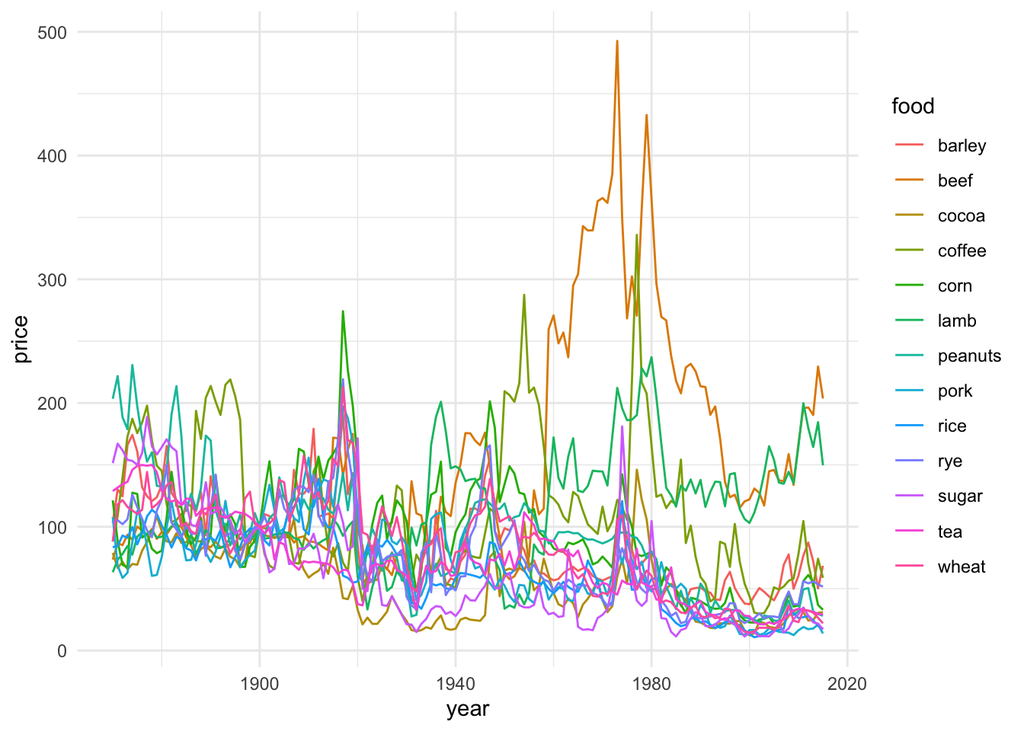

```r
food_prices |>
  pivot_longer(-year, names_to = "food", values_to = "price") |>
  ggplot() +
    geom_line(aes(x = year, y = price, color = food))
```

Drawing this plot with the original data set would require manually including a layer for each food type, selecting their colors, and building a manual legend. The alternative using the longer table is certainly the preferred approach.

## Pivot wider

To illustrate making a table wider, let’s create a new data set consisting of the long format of the food prices data set from just the years 1950 and 1975:

```r
food_prices_long <- food_prices |>
  pivot_longer(-year, names_to = "food", values_to = "price") |>
  filter(year %in% c(1950, 1975))
```

As described in our motivating example, it makes sense for some analyses to make each time point a column in a wider data set. To do this, we use the `pivot_wider` function. We need to indicate the current feature contains the values that will become new columns and the feature from which to take the values for the new column from. Here, the names will come from the `years` column (we want a new column for 1950 and another one for 1975) and the values will be filled in with prices.

```r
food_prices_long |>
  pivot_wider(names_from = year, values_from = price)
```

```
## # A tibble: 13 × 3
##    food    `1950` `1975`
##    <chr>    <dbl>  <dbl>
##  1 tea       68.9   54.1
##  2 sugar     59.5  114.
##  3 peanuts  119.    95.6
##  4 coffee   210.   105.
##  5 cocoa     64.6   54.1
##  6 wheat    106.    74.8
##  7 rye       88.4   71.2
##  8 rice      62.7   74.2
##  9 corn     135.   113.
## 10 barley    98.8   91.3
## 11 pork      52.3   88.8
## 12 beef      62.4  268.
## 13 lamb      33.8  186.
```

One problem with the default output is that the column names now start with a number, which is not an allowed variable name in R. This makes it awkward to work with the data set; it is better to add a prefix to the names to make them valid. This can be done by setting the `names_prefix` option in the `pivot_wider` function.

```r
food_prices_long |>
  pivot_wider(
    names_from = year, values_from = price, names_prefix = "year_"
  )
```

```
## # A tibble: 13 × 3
##    food    year_1950 year_1975
##    <chr>       <dbl>     <dbl>
##  1 tea          68.9      54.1
##  2 sugar        59.5     114.
##  3 peanuts     119.       95.6
##  4 coffee      210.      105.
##  5 cocoa        64.6      54.1
##  6 wheat       106.       74.8
##  7 rye          88.4      71.2
##  8 rice         62.7      74.2
##  9 corn        135.      113.
## 10 barley       98.8      91.3
## 11 pork         52.3      88.8
## 12 beef         62.4     268.
## 13 lamb         33.8     186.
```

This new form of the data set makes it straightforward to plot the price of each food type in 1975 as a function of its price in 1950.

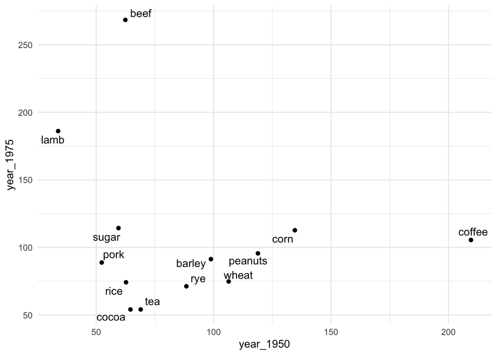

```r
food_prices_long |>
  pivot_wider(names_from = year, values_from = price, names_prefix = "year_") |>
  ggplot() +
    geom_point(aes(x = year_1950, y = year_1975)) +
    geom_text_repel(aes(x = year_1950, y = year_1975, label = food))
```

We can add some of the polishing touches mentioned in Notebook07 to make the plot even more readable.

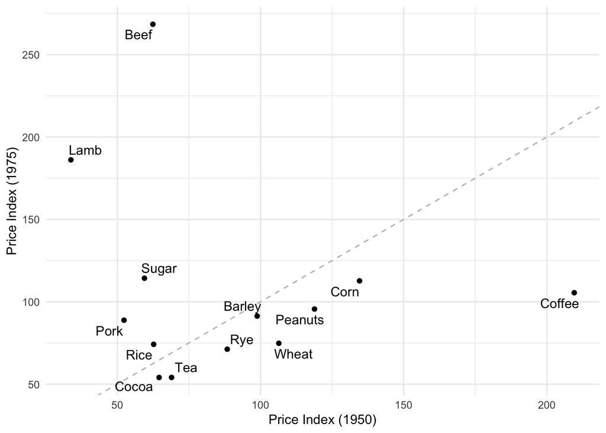

```r
food_prices_long |>
  pivot_wider(names_from = year, values_from = price, names_prefix = "year_") |>
  mutate(food = stri_trans_totitle(food)) |>
  ggplot() +
    geom_abline(slope = 1, intercept = 0, linetype = "dashed", color = "grey") +
    geom_point(aes(x = year_1950, y = year_1975)) +
    geom_text_repel(aes(x = year_1950, y = year_1975, label = food)) +
    labs(x = "Price Index (1950)", y = "Price Index (1975)")
```

In this new plot, can you see what products got much more expensive, much less expensive, and stayed about the same from 1950 to 1975?

## Patterns for table pivots

The syntax for making tables wider or longer is, on the surface, not much more complex than other table verbs that we have covered in this text. The biggest challenges with table pivots are identifying when they will simplify an analysis and not over-using them. The best way to avoid these issues is to store your data in the longest format that makes sense for your data. For example, in the motivating example about plant growth, it is better to store the data with 1400 rows and 3 columns.

Perhaps the biggest benefit of storing data in a longer format is to avoid the potentially complex chain of operations required to make the plot at the end of the previous section. The original data set is stored with years as rows and items as columns. Producing the plot requires thinking of years and columns and items as rows; this needed us to first pivot longer and then pivot wider. Keeping data in a longer format avoids the need for double pivots, while also making the different kinds of analysis (item and year, year by item, item by year) all reasonable accessible.

In my experience, some social scientists have a bad habit of storing data in extremely wide and unwieldy formats. It seems to be something that comes from the way that feels natural to organize survey and time-series data sets. For example, the U.S. Census Bureau produces data sets that often have hundreds of columns. Keep this in mind as you collect your own data, or work with external sources. Often an analysis that looks difficult at first will appear quite straightforward after pivoting your data set to a longer format.

## Homework Questions

Consider the following subset of the `hans` dataset:

```
## # A tibble: 8 × 3
##   country        year    gdp
##   <chr>         <dbl>  <dbl>
## 1 China          1957   576.
## 2 China          2007  4959.
## 3 France         1957  8663.
## 4 France         2007 30470.
## 5 Mexico         1957  4132.
## 6 Mexico         2007 11978.
## 7 United States  1957 14847.
## 8 United States  2007 42952.
```

Answer the following four questions:

1. Re-write the table that would result from pivoting the table wider by turning the countries into columns.
2. Re-write the table that would result from pivoting the table wider by turning the years into columns.
3. Sketch a plot showing a graphic that would be easy to make with the data from question one, but hard from the original data.
4. Sketch a plot showing a graphic that would be easy to make with the data from question two, but hard from the original data.

## Homework Answers

1. **Re-write the table that would result from pivoting the table wider by turning the countries into columns.**

```
## # A tibble: 2 × 5
##    year China France Mexico `United States`
##   <dbl> <dbl>  <dbl>  <dbl>           <dbl>
## 1  1957  576.  8663.  4132.          14847.
## 2  2007 4959. 30470. 11978.          42952.
```

2. **Re-write the table that would result from pivoting the table wider by turning the years into columns.**

```
## # A tibble: 4 × 3
##   country       year_1957 year_2007
##   <chr>             <dbl>     <dbl>
## 1 China              576.     4959.
## 2 France            8663.    30470.
## 3 Mexico            4132.    11978.
## 4 United States    14847.    42952.
```

3. **Sketch a plot showing a graphic that would be easy to make with the data from question one, but hard from the original data.**

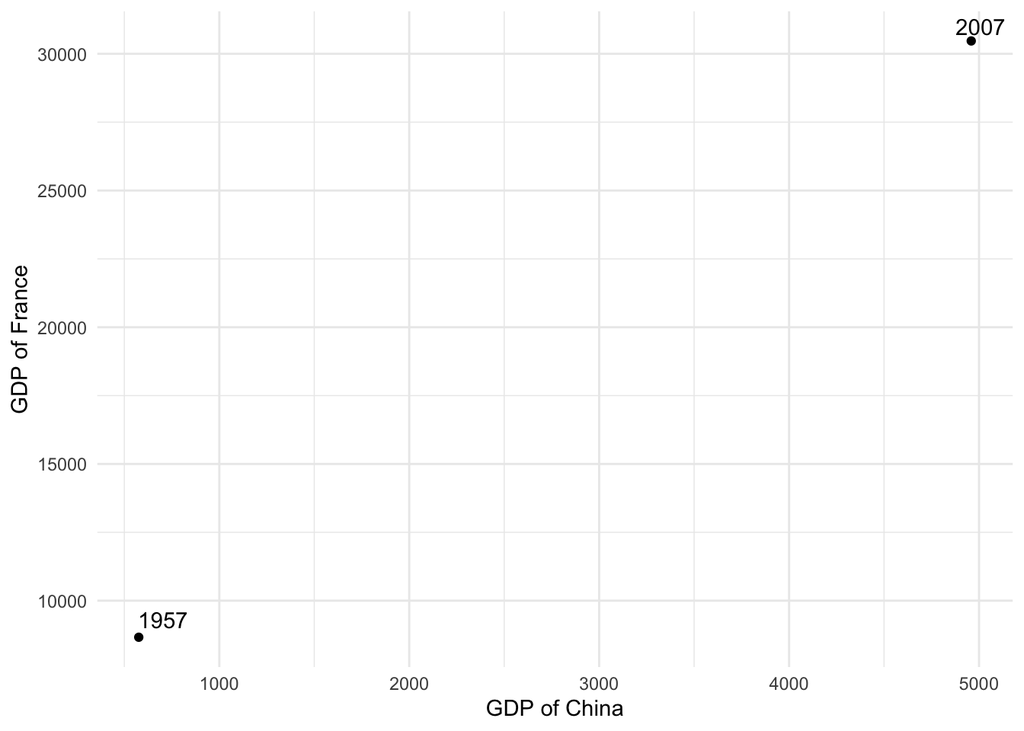

4. **Sketch a plot showing a graphic that would be easy to make with the data from question two, but hard from the original data.**

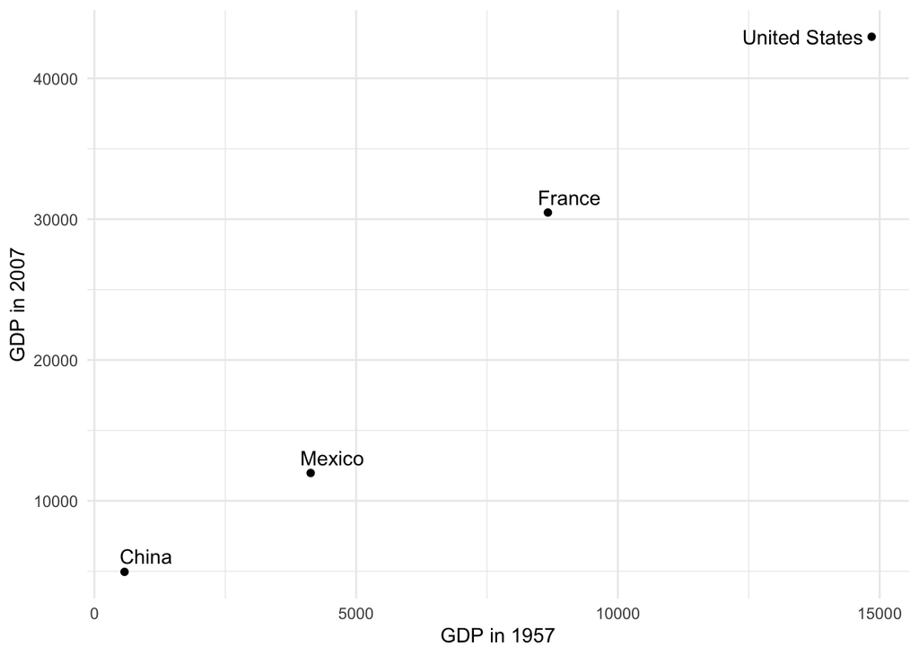